# Job Posting Analysis

**Business Objectives:**  
Our main business objectives are to understand the dynamics of the labour market of Armenia using the online job portal post.  
Business questions answering to our business objectives are defined as follows:  
**Job Nature and Company Profiles:**  
What are the types of jobs that are in demand in Armenia? How are the job natures changing over time?  
**Desired Characteristics and Skill-Sets:**  
What are the desired characteristics and skill-set of the candidates based on the job description dataset? How these are desired characteristics changing over time?  
**IT Job Classification:**  
Build a classifier that can tell us from the job description and company description whether a job is IT or not, so that this column can be automatically populated for new job postings. After doing so, understand what important factors are which drives this classification.  
**Similarity of Jobs:**  
Given a job title, find the 5 top jobs that are of a similar nature, based on the job post.  
**Text Mining Goals:**  
The text mining goals is a set of sub-goals to answer our business questions: For the IT Job classification business question, you should aim to create supervised learning classification models that are able to classify based on the job text data accurately, is it an IT job.

**Approach**

**Part 1**

**1 Importing the libraries**  
**2 Data Audits**

> - Check for duplicates
> - Check for missing values
> - Check language of the data

**3 Exploratory Data Analysis**

> - Job postings by year
> - JOb postings by month
> - Top companies posting the jobs
> - Length of job post for each entry

**4 Preliminary data preparation**

> - Imputing the missing values with mode for categorical variables
> - Imputing the missing values with median for numerical variables
> - Removing the duplicate rows

**5 Data Preparation**

> - Selecting features based on business
> - Data Cleaning
>   > - Removing symbols, punctuations
>   > - Changing to lower case
>   > - Lemmatization / Stemming
>   > - Removal of stop words
>   > - Removing words except nouns, adjectives, verbs using POS tagging

**6 Testing the Frequency distribution of the 'Software developer' job title**

**7 IT job classification**

> - Supervised learning
>   > - TF-IDF model
>   > - Dimensionality Reduction (Singular Value Decomposition (SVD))
>   > - Over sampling (SMOTE)
>   > - Model Implementation + Evaluation
>   >   > - LinearSVC
>   >   > - Logistic Regression

**8 Job Qualification Clustering**

> - K Means
> - Train and Test split
> - Tokenization
> - Dimensionality Reduction (Singular Value Decomposition (SVD))
> - Finding the Optimum #Clusters (Silhouette Analysis)
> - Model Implementation
> - Cluster Inspection

**9 Job skills requirement Entities**

> - Named Entity Recogition

**Part 2**

**10 Job topics**

> - Topic modelling (LDA)
>   > - Model Implementation
>   > - Analysis of the Topics derived
>   > - Topic frequencies
>   > - Visualization using pyLDAvis
> - Observing the changes in the Job topics over time

**11 Company profiles analysis**

> - Applying Information Extraction on Companies profiles (Pattern Matching)
> - Defining the patterns and the frequency analysis

**12 Job Similarity**

> - TF-IDF vectorization
> - Cosine simialrity
> - Analyzing the similar jobs for each job

**13 Findings and Recommendations**

### ----------------------------------------------------------------------------------------------------------------------------

Importing the Libraries

```python
import numpy as np
import pandas as pd
import seaborn as sns
import pickle
from matplotlib import pyplot as plt
%matplotlib inline
plt.rcParams['figure.figsize'] = 10, 7.5
plt.rcParams['axes.grid'] = True
from tqdm import tqdm_notebook

import re
import nltk
import spacy
import gensim

from nltk.corpus import stopwords
from nltk.stem.porter import PorterStemmer
from nltk.stem import WordNetLemmatizer
from nltk.tokenize import word_tokenize

from sklearn.model_selection  import train_test_split
from sklearn.metrics import confusion_matrix, classification_report, accuracy_score, roc_auc_score, silhouette_score
```

Importing the data

```python
data = pd.read_csv('data job posts.csv')
```

```python
data.head(3)
```

|  | jobpost | date | Title | Company | AnnouncementCode | Term | Eligibility | Audience | StartDate | Duration | ... | Salary | ApplicationP | OpeningDate | Deadline | Notes | AboutC | Attach | Year | Month | IT |
| --- | --- | --- | --- | --- | --- | --- | --- | --- | --- | --- | --- | --- | --- | --- | --- | --- | --- | --- | --- | --- | --- |
| 0 | AMERIA Investment Consulting Company\nJOB TITL... | Jan 5, 2004 | Chief Financial Officer | AMERIA Investment Consulting Company | NaN | NaN | NaN | NaN | NaN | NaN | ... | NaN | To apply for this position, please submit a\nc... | NaN | 26 January 2004 | NaN | NaN | NaN | 2004 | 1 | False |
| 1 | International Research & Exchanges Board (IREX... | Jan 7, 2004 | Full-time Community Connections Intern (paid i... | International Research & Exchanges Board (IREX) | NaN | NaN | NaN | NaN | NaN | 3 months | ... | NaN | Please submit a cover letter and resume to:\nI... | NaN | 12 January 2004 | NaN | The International Research & Exchanges Board (... | NaN | 2004 | 1 | False |
| 2 | Caucasus Environmental NGO Network (CENN)\nJOB... | Jan 7, 2004 | Country Coordinator | Caucasus Environmental NGO Network (CENN) | NaN | NaN | NaN | NaN | NaN | Renewable annual contract\nPOSITION | ... | NaN | Please send resume or CV toursula.kazarian@...... | NaN | 20 January 2004\nSTART DATE: February 2004 | NaN | The Caucasus Environmental NGO Network is a\nn... | NaN | 2004 | 1 | False |

3 rows × 24 columns

**Data Audit**

```python
data.shape
```

```
(19001, 24)
```

Check for duplicate rows

```python
data.duplicated().value_counts()
```

```
False    18962
True        39
dtype: int64
```

Check for the missing values

```python
data.isnull().sum()
```

```
jobpost                 0
date                    0
Title                  28
Company                 7
AnnouncementCode    17793
Term                11325
Eligibility         14071
Audience            18361
StartDate            9326
Duration             8203
Location               32
JobDescription       3892
JobRequirment        2522
RequiredQual          484
Salary               9379
ApplicationP           60
OpeningDate           706
Deadline               65
Notes               16790
AboutC               6531
Attach              17442
Year                    0
Month                   0
IT                      0
dtype: int64
```

### ----------------------------------------------------------------------------------------------------------------------------

**Exploratory Analysis**

Job postings by Year

```python
yr=pd.DataFrame(data.Year.value_counts().reset_index())
yr['post_count']=yr.Year
yr.Year = yr['index']
yr.sort_values(by='Year',inplace=True)
yr.drop(columns='index',inplace =True)
```

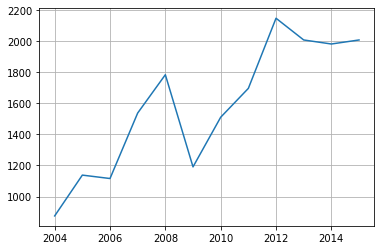

```python
plt.plot('Year','post_count',data=yr)
plt.show()
```

Job postings by month

```python
mon=pd.DataFrame(data.Month.value_counts().reset_index())
mon['post_count']=mon.Month
mon['Month']=mon['index']
mon.drop('index',axis=1,inplace=True)
mon.sort_values(by='Month',inplace=True)
```

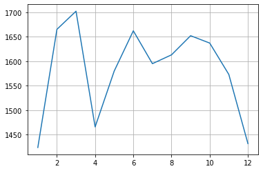

```python
plt.plot('Month','post_count',data=mon)
plt.show()
```

Top companies posting jobs

```python
com=pd.DataFrame(data.Company.value_counts().reset_index())
com['post_count']=com.Company
com['Company']=com['index']
com.drop('index',axis=1,inplace=True)
com.sort_values(by='post_count',inplace=True,ascending=False)
```

```python
len(com.Company.unique())
```

```
4554
```

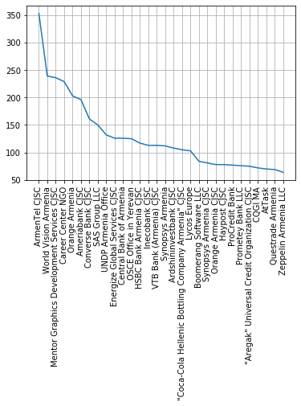

```python
plt.plot('Company','post_count',data=com.head(30))
plt.xticks(rotation=90)
plt.show()
```

Length of the job post for each entry

```python
words=[]
for i in range(data.shape[0]):
    words.append(len(data.jobpost.iloc[i].split()))
```

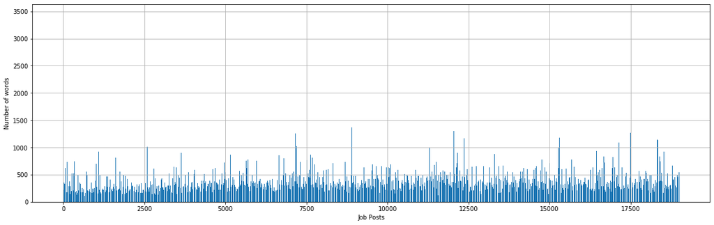

```python
plt.figure(figsize=(20,6))
plt.bar(x=data.index,height=words)
plt.xlabel('Job Posts')
plt.ylabel('Number of words')
plt.show()
```

### ----------------------------------------------------------------------------------------------------------------------------

**Preliminary data preparation**

Imputing Missing values with mode

```python
Column_dtype = dict(data.dtypes)
num_col=[key for key in Column_dtype if Column_dtype[key] in ['float64', 'int64', 'float32', 'int32','bool']]
cat_col=[key for key in Column_dtype if Column_dtype[key] in ['object']]
```

```python
num_col
```

```
['Year', 'Month', 'IT']
```

```python
print(cat_col)
```

```
['jobpost', 'date', 'Title', 'Company', 'AnnouncementCode', 'Term', 'Eligibility', 'Audience', 'StartDate', 'Duration', 'Location', 'JobDescription', 'JobRequirment', 'RequiredQual', 'Salary', 'ApplicationP', 'OpeningDate', 'Deadline', 'Notes', 'AboutC', 'Attach']
```

```python
data_cat = data[cat_col]
data_num = data[num_col]
```

```python
def miss_treat_cat(x):
    #x = x.fillna(x.mode())
    x[x.isnull()] = x.mode()[0]
    return x

data_cat = data_cat.apply(miss_treat_cat)
```

```python
#Check for the null values
data_cat.isnull().sum().value_counts()
```

```
0    21
dtype: int64
```

```python
def outlier_miss_treat(x):
    x = x.clip(upper = x.quantile(0.99))
    x = x.clip(lower = x.quantile(0.01))
    x = x.fillna(x.median())
    return x

data_num = data_num.apply(outlier_miss_treat)
```

```python
data_num.isnull().sum().value_counts()
```

```
0    3
dtype: int64
```

```python
data = pd.concat([data_cat, data_num], axis=1)
```

```python
data.shape, data_num.shape, data_cat.shape
```

```
((19001, 24), (19001, 3), (19001, 21))
```

Treating the duplicate rows

```python
data = data[~data.duplicated()]
```

```python
data.duplicated().value_counts()
```

```
False    18962
dtype: int64
```